# Ciência de Dados para Todos (Data Science For All) - 2018.1 - Análise da Produção Científica e Acadêmica da Universidade de Brasília - Relatório Final da Disciplina - Departamento de Ciência da Comput

## Publicações PPG MAT

Além disso, podemos notar que temos um maior número de publicações em eventos, artigos e capítulos de livro. Participações em eventos geralmente evidenciam algum tipo de engajamento dos pesquisadores com as comunidades externas à universidade e podem trazer informações importantes sobre o quanto determinado departamento influencia ou é influenciado por outras comunidades.

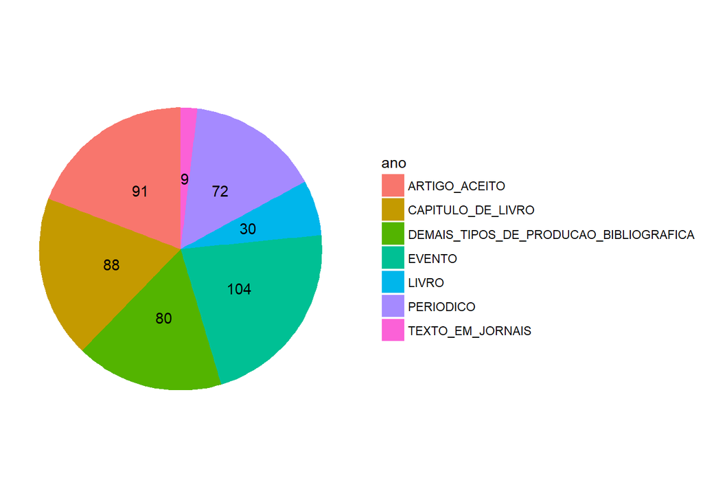

```r
publicacoes <- fromJSON("Matematica.publication.json")

x = c()
for (i in publicacoes) {
  x <- append(sum(sapply(i, length)), x)
}

data.frame(numero_pesquisas = x, ano = names(publicacoes)) %>%
  ggplot(aes(x = "", y = numero_pesquisas, fill = ano)) +
  geom_bar(width = 1, stat = "identity") +
  geom_text(aes(label = paste0(round(numero_pesquisas), "")),
            position = position_stack(vjust = 0.5)) +
  coord_polar("y") +
  theme_void()
```

A seguir, temos dois gráficos que mostram o número de eventos de acordo o ano e país do evento. Podemos notar que o PPG participou de um maior número de eventos em 2014, 2012 e 2011, respectivamente. O que indica uma queda considerável no número de participações. Também podemos perceber que o PPG participa de vários eventos nos Estados Unidos e que há um número considerável de artigos aceitos que pode ser tanto em eventos/periódicos nacionais quanto internacionais.

Usando `length(unique(pub.df3$periodico))` obtemos como resposta 243, um número grande de publicações em periódicos **diferentes** de Matemática.

Esses dados indicam um grau considerável de intercionalização do programa uma vez que o segundo país com maior número de participação de eventos de membros do programa é o Estados Unidos - 38 - e não há barreiras linguísticas para as publicações, visto que boa parte de suas produções são em periódicos internacionais .

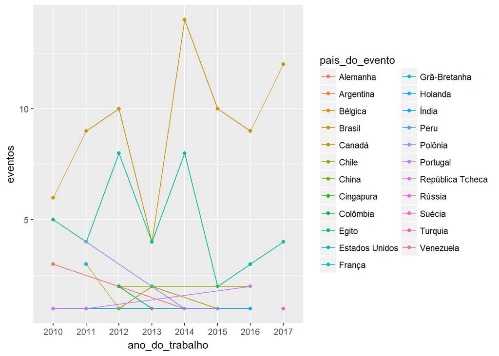

```r
pub.df <- data.frame()
for (i in 1:length(publicacoes$ARTIGO_ACEITO))
   pub.df <- rbind(pub.df, publicacoes$ARTIGO_ACEITO[[i]])
glimpse(pub.df)
unique(pub.df$ano)

pub.df2 <- data.frame()
for (i in 1:length(publicacoes$EVENTO))
  pub.df2 <- rbind(pub.df2, publicacoes$EVENTO[[i]])
glimpse(pub.df2)

pub.df2 %>%
  group_by(pais_do_evento, ano_do_trabalho) %>%
  summarise(eventos = n()) %>%
  arrange(desc(eventos)) %>%
  ggplot(aes(x = ano_do_trabalho, y = eventos, col = pais_do_evento,
             group = pais_do_evento)) +
  geom_point() +
  geom_line()
```

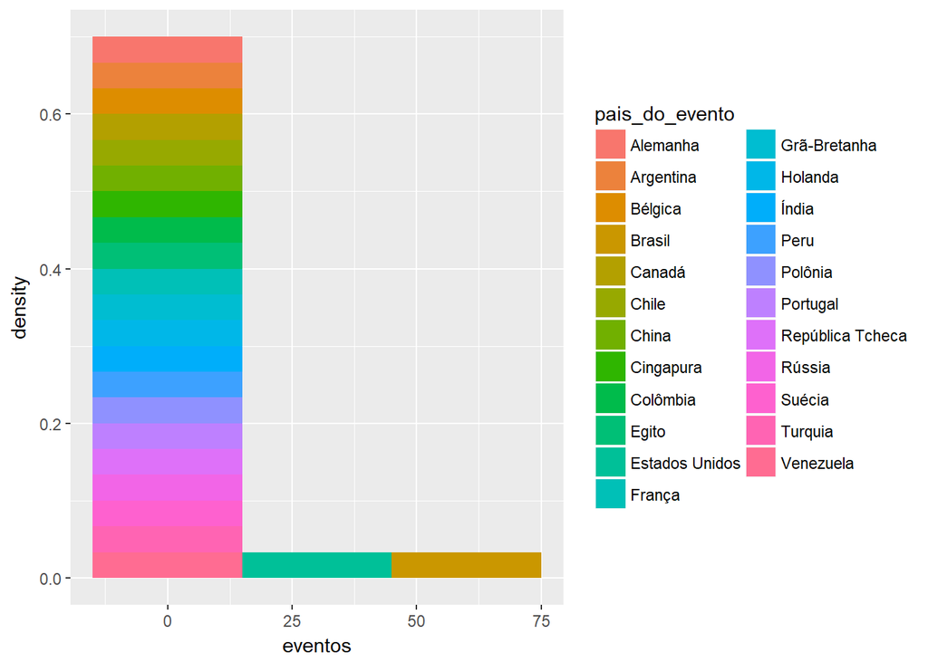

```r
pub.df2 %>%
  group_by(pais_do_evento) %>%
  summarise(eventos = n()) %>%
  arrange(desc(eventos)) %>%
  ggplot(aes(eventos, fill = pais_do_evento)) +
  geom_histogram(aes(y = ..density..), binwidth = 30)
```

```r
pub.df3 <- data.frame()
for (i in 1:length(publicacoes$PERIODICO))
   pub.df3 <- rbind(pub.df3, publicacoes$PERIODICO[[i]])
glimpse(pub.df3)
length(unique(pub.df3$periodico))
```

## Orientações PPG MAT

No gráfico abaixo temos o número de bolsistas do programa. Boa parte das bolsas se concentram no grupo que está fazendo dissertação de mestrado, o que já era de se esperar pois há um maior número de Mestrandos do que de Doutorandos, analisando o DataSet **OASIS**.

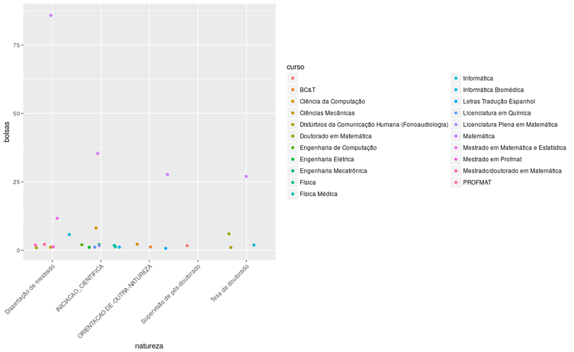

Além disso, 2014 foi o ano com o maior número de bolsistas: 47 do total de 236 bolsas avaliadas desde 2010. O número de bolsas sofreu um grande aumento em relação à anos anteriores, o que indica crescimento e desenvolvimento do programa desde 2010. Entretanto, em 2017 este número caiu para 29. Que pode ser interpretado como uma reflexão do menor número de mestrandos no programa ou um menor número de bolsas disponíveis.

O ano de 2014 também foi o ano com resultados mais expressivos para publicações do programa, conforme comentado anteriormente. Isso nos mostra uma relação direta entre o número de bolsas para orientações e publicações.

## PPG Matematica Rede

O dataset MatematicaRedeResearchers.json contém todas as áreas em que existem algum tipo de produção científica, a nível de pós-graduação, produzida ou em produção até 2017 por membros do Departamento de Matemática. Como é possível notar os temas desenvolvidos não são exculivamente da Matemática ou ainda das Ciências Exatas, existe uma flexibilização que permite ao pesquisador trabalhar em diferentes campos do saber. Outro dado interessante é o desenvolvimento de trabalhos na área da educação o que valida as informações apresentadas no site do departamento onde são apresentados diversos projetos nesse âmbito.

- print(administração)
- ## [1] 1
- print(educação)
- ## [1] 4
- print(engBioMédica)
- ## [1] 1
- print(matemática)
- ## [1] 26
- print(ProbeEstat)
- ## [1] 2
- print(Psicologia)
- ## [1] 2

```
##  chr [1:2] "0556476746202406" "5874654544324539"
```

De posse dos IDs é possível fazer algumas observações, para tal foi adicionado o dataset MatematicaRede.profile.json que contém o perfil Lattes de todos os membros do departamento. De posse dessas informações é possível comprovar a existência dos pesquisadores com os ID que foram encontrados e ainda verificar se eles, mesmo sendo “nativos” da Matemática, possuem alguma pesquisa na área da Psicologia olhando suas áreas de atuação:

```r
str(pesq1 <- data_frame(perfil$`0556476746202406`$areas_de_atuacao$area))
```

```
## Classes 'tbl_df', 'tbl' and 'data.frame':    3 obs. of  1 variable:
##  $ perfil$`0556476746202406`$areas_de_atuacao$area: chr  "Matemática" "Educação" "Psicologia"
```

```r
str(pesq2 <- data_frame(perfil$`5874654544324539`$areas_de_atuacao$area))
```

```
## Classes 'tbl_df', 'tbl' and 'data.frame':    4 obs. of  1 variable:
##  $ perfil$`5874654544324539`$areas_de_atuacao$area: chr  "Matemática" "Educação" "Educação" "Psicologia"
```

Ainda sobre as áreas de pesquisa é possível notar, como talvez já fosse esperado, que as sub-áreas da Matemáticas são majoritariamente as mais buscadas para desenvolvimento de pesquisas e isso pode ser verificado no gráfico a seguir que mostra a distribuição das pesquisas por área e diante do número pode-se afirmar que as sub-áres da Matemática são as de maior interesse e por consequência possuem os **resultados mais relevantes**.

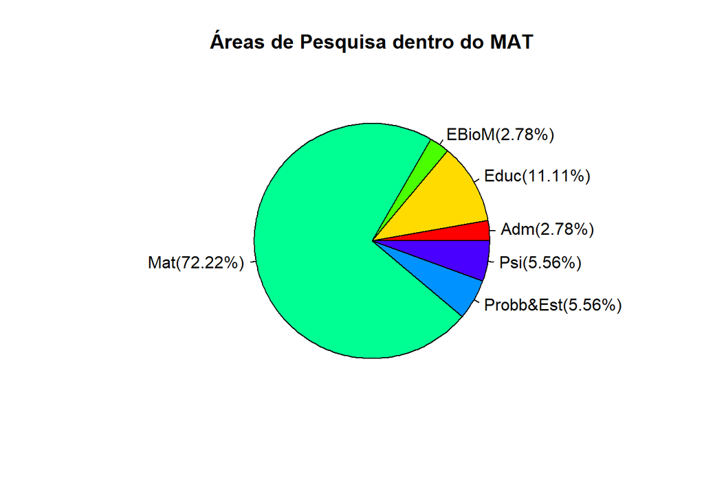

```r
resumo_pesq1 <- (perfil$`0556476746202406`$resumo_cv )
resumo_pesq2 <- (perfil$`5874654544324539`$resumo_cv)
resumo_pesq1
```

```
## [1] "Professor Associado I na Universidade de Brasília - UnB, com lotação no Departamento de Matemática. É membro do Programa de Pós-Graduação em Educação da UnB, orientando pesquisas nos cursos de mestrado acadêmico e doutorado em educação. Possui graduação em Licenciatura em Ciências e Matemáti…
```

```r
resumo_pesq2
```

```
## [1] "Possui Licenciatura em Matemática (1995) e Especialização em Matemática (1998) pela Universidade Federal de Goiás, Mestrado em Educação (2002) e Doutorado em Psicologia (2008) pela Universidade de Brasília. Tem experiência profissional: 1) na Educação Básica como docente de matemática e coor…
```

Outro dado interessante é analisar o nível de internacionalização das produções dos pesquisadores, isso pode ser analisado com a quantidade de participações em eventos internacionais e nacionais.Como é possível ver através dos gráficos a internacionalização das pequisas pode ser considerada baixa, porém existe forte participação desses pesquisadoes em âmbito nacional.

#### Pesquisador ID_0556476746202406

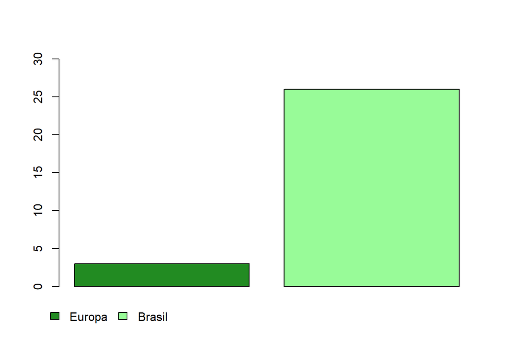

#### Pesquisador ID_5874654544324539

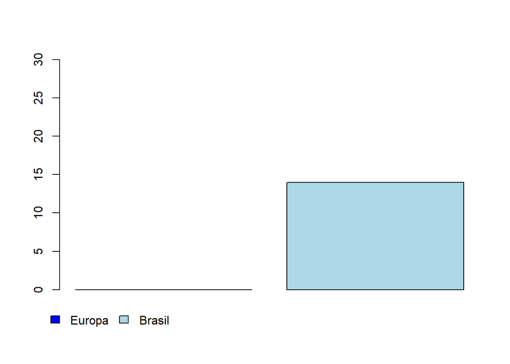

# CRISP-DM Fase.Atividade 5 - Avaliação dos resultados

Quanto ao estudos dos datasets da Matemática, permitiu-se tirar conclusões acerca de seu programa de pós-graduação e validar as informações contidas no site do programa. Assim como havia sido afirmado anteriormente o Departamento é capaz de oferecer oportunidades de estudo em diversos campos do saber, ainda assim não deixa de privilegiar as sub-áreas das Ciências Exatas como a Álgebra e a Estatística. De acordo com os resultados obtidos é possível notar que as áreas de pós-graduação dentro da Matemática que não trabalham diretamente com sub-áreas das exatas não possuem o mesmo grau de internacionalização que as demais, porém por serem numericamente inferiores não tem impacto direto na nota do curso que é alta, outra informação que foi validade de acordo com o que está no site do programa.

# CRISP-DM Fase.Atividade 6 - Revisão sobre a execução do projeto

O trabalho feito visou o estudo de tudo aquilo que é produzido cientificamente pela universidade (ciência da ciência) e qual a relevância destas descobertas para os próprios pesquisadores e alunos, com o intuito de validarem o método que utilizam e a qualidade daquilo que vem sendo criado.

A mais antiga das ciências da ciência é a filosofia. A tarefa da filosofia consistiu, durante séculos, em estabelecer o melhor método do conhecimento verdadeiro, e depois aplicá-lo para o entendimento do mundo, da religião e da moral. A ciência da ciência é hoje uma atividade multi-disciplinar, com muitas abordagens distintas.

O pensamento lógico já se demonstrou ineficiente para criação de teorias científicas e para descrever a natureza. René Descartes, já afirmava que: ``Matemática é uma ferramenta para se fazer ciência, mas não é uma ciência’’. Isso ocorre, pois palavras e números não existem na natureza, portanto não são ciência. Mas, a matemática já se mostrou ótima ferramenta para o estudo e formulação de teorias científicas.

A Matemática é essencial para muitas ciências. A função mais importante da Matemática na ciência é o papel que ela possui na expressão de modelos científicos. Medidas de coleta e observação, bem como hipotetizar e prever, geralmente requerem modelos matemáticos e um extensivo uso da Matemática. Os ramos matemáticos mais utilizados na ciência incluem o cálculo e a estatística, apesar de virtualmente cada ramo da Matemática ter aplicações, mesmo áreas “puras” tais como a teoria numérica e a topologia. A Matemática prevalece mais na Física, e menos em Química e algumas ciências sociais. Alguns pensadores vêem os matemáticos como cientistas, considerando os experimentos físicos como não essenciais ou as provas matemáticas como equivalentes a experimentos. Outros não vêem a Matemática como ciência, já que ela não requer teste experimental de suas teorias e hipóteses. Em qualquer caso, o fato de que a Matemática é uma ferramenta útil na descrição do universo é uma questão da Filosofia da Matemática. Richard Feynman disse: “A Matemática não é real, mas se sente real. Onde é esse lugar?”, enquanto que a definição favorita de Bertrand Russell sobre a Matemática é ``o assunto no qual nunca sabemos do que estamos falando nem se o que estamos dizendo está certo.’’

O programa de pós-graduação sendo avaliado gerou ao longo dos anos diversos subprodutos que são consequências direta da atividade cientifica como por exemplo publicações e ou orientações acadêmicas que podem ser avaliadas para gerar um feedback qualitativo sobre o programa. Algumas questões devem ser levantadas ao realizar estes estudos, entre elas como definir uma métrica para o que está sendo avaliado? Sabemos que grande parte das bases de dados internacionais indexam apenas pesquisas realizadas em língua inglesa, portanto como é possível avaliar o impacto internacional do que é produzido no país?

Estas questões são discutidas e exploradas na ciência da ciência poís devemos ser capazes de medir e validar o impacto do que é produzido em nossas universidade e como é possível melhorar o que vem sendo produzido. Existem grupos de pesquisa como por exemplo o Science and Evaluation Studies(SES) que se dedicam exclusivamente ao estudo de métricas de avaliações de pesquisas cientificas.

A plataforma Lattes vem com o objetivo de auxiliar nos estudos acerca da produção realizada na universidade. Diversos conjuntos de dados acadêmicos são agregados com o intuito de gerar um material organizado e padronizado para que outros usuários possam disfrutar destas informações. Os estudos aqui realizados se baseiam nos conjuntos de dados fornecidos a respeito de publicações, orientações e perfis agregados pela própria plataforma do Lattes que se tornou bastante relevante no momento de definir nossas métricas de avaliação.

# Referências

- Azevedo, Mário Luiz Neves de, João Ferreira de Oliveira, e Afrânio Mendes Catani. “O Sistema Nacional de Pós-Graduação (SNPG) e o Plano Nacional de Educação (PNE 2014-2024): regulação, avaliação e financiamento”. Revista Brasileira de Política e Administração da Educação 32, nº 3 (2016). http://dx.doi.org/10.21573/vol32n32016.68576.
- Can, Fazli, Tansel Özyer, e Faruk Polat, orgs. State of the Art Applications of Social Network Analysis. Lecture Notes in Social Networks. Switzerland: Springer International Publishing, 2014.
- CAPES. “Documentos de Área”. CAPES.gov.br. Acessado 12 de junho de 2018. http://avaliacaoquadrienal.capes.gov.br/documentos-de-area.
- ———. “Plano Nacional de Pós-Graduação - PNPG 2011/2020 Vol. 1”. Brasília - DF, dezembro de 2010. http://www.capes.gov.br/images/stories/download/Livros-PNPG-Volume-I-Mont.pdf.
- ———. “Plano Nacional de Pós-Graduação - PNPG 2011/2020 Vol. 2”. Brasília - DF, dezembro de 2010. http://www.capes.gov.br/images/stories/download/PNPG_Miolo_V2.pdf.
- ———. “Sucupira: coleta de dados, docentes de pós-graduação stricto sensu no Brasil 2015”. CAPES - Banco de Metadados, 16 de março de 2016. http://metadados.capes.gov.br/index.php/catalog/63.
- Chapman, Pete, Julian Clinton, Randy Kerber, Thomas Khabaza, Thomas Reinartz, Colin Shearer, e Rüdiger Wirth. “CRISP-DM 1.0: Step-by-Step Data Mining Guide”. USA: CRISP-DM Consortium, 2000. https://www.the-modeling-agency.com/crisp-dm.pdf.
- Datacamp. “Machine Learning with R (Skill Track)”. Datacamp, 2018. https://www.datacamp.com/tracks/machine-learning.
- Fernandes, Jorge H C, e Ricardo Barros Sampaio. “DataScienceForAll”. Zotero, 13 de junho de 2018. https://www.zotero.org/groups/2197167/datascienceforall.
- ———. “Especificação do Trabalho Final da Disciplina de Ciência de Dados para Todos 2017.2: Estudo sobre a visibilidade internacional da produção científica das pós-graduações vinculadas às áreas de conhecimento da CAPES, na Universidade de Brasília (Comunicação Interna)”. Disciplina 116297 - Tópicos Avançados em Computadores, turma D, do semestre 2017.2, do Departamento de Ciência da Computação do Instituto de Ciências Exatas da Universidade de Brasília, 28 de novembro de 2017. https://aprender.ead.unb.br/pluginfile.php/474549/mod_resource/content/1/Estudo%20da%20Cie%CC%82ncia.pdf.
- Fernandes, Jorge H C, Ricardo Barros Sampaio, e João Ribas de Moura. “Ciência de Dados para Todos (Data Science For All) - 2018.1 - Análise da Produção Científica e Acadêmica da Universidade de Brasília - Modelo de Relatório Final da Disciplina - Departamento de Ciência da Computação da UnB”. Disciplina 116297 - Tópicos Avançados em Computadores, turma D, do semestre 2018.1, do Departamento de Ciência da Computação do Instituto de Ciências Exatas da Universidade de Brasília, 13 de junho de 2018.
- Frickel, Scott, e Kelly Moore. The New Political Sociology of Science: Institutions, Networks, and Power. Science and technology in society. USA: The University of Wisconsin Press, 2006.
- Graduate Prospects Ltd. “Job profile: Higher education lecturer”, 2018. https://www.prospects.ac.uk/job-profiles/higher-education-lecturer.
- Kalpazidou Schmidt, Evanthia, e Ebbe Krogh Graversen. “Persistent factors facilitating excellence in research environments”. Higher Education 75, nº 2 (1º de fevereiro de 2018): 341–63. https://doi.org/10.1007/s10734-017-0142-0.
- Kilduff, Martin, e Wenpin Tsai. Social Networks and Organizations. UK: Sage Publications, 2003.
- Kolaczyk, Eric D., e Gábor Csárdi. Statistical Analysis of Network Data with R. USA: Springer, 2014.
- Kuhn, Max, Jed Wing, Steve Weston, Andre Williams, Chris Keefer, Allan Engelhardt, Tony Cooper, et al. “Package ‘Caret’ - Classification and Regression Training”, 27 de maio de 2018. https://cran.r-project.org/web/packages/caret/caret.pdf.
- Leite, Fernando César Lima. “Considerações básicas sobre a Avaliação do Sistema Nacional de Pós-Graduação”. Comunicação Pessoal (slides). Universidade de Brasília, abril de 2018. https://aprender.ead.unb.br/pluginfile.php/502250/mod_resource/content/1/Considera%C3%A7%C3%B5es%20b%C3%A1sicas%20sobre%20a%20Avalia%C3%A7%C3%A3o%20do%20Sistema%20Nacional.pdf.
- Lusher, Dean, Johan Koskinen, e Garry Robins, orgs. Exponential Random Graph Models for Social Networks: Theory, methods, and applications. Structural Analysis in the Social Sciences. USA: Cambridge University Press, 2013.
- Mariscal, Gonzalo, Óscar Marbán, e Covadonga Fernández. “A survey of data mining and knowledge discovery process models and methodologies”. The Knowledge Engineering Review 25, nº 2 (2010): 137–66. https://doi.org/10.1017/S0269888910000032.
- Nery, Guilherme, Ana Paula Bragaglia, Flávia Clemente, e Suzana Barbosa. “Nem tudo parece o que é: Entenda o que é plágio”. Instituto de Arte e Comunicação Social da UFF, 2009. http://www.noticias.uff.br/arquivos/cartilha-sobre-plagio-academico.pdf.
- Nooy, Wouter de, Andrej Mrvar, e Vladimir Batagelj. Exploratory Social Network Analysis with Pajek. Structural Analysis in the Social Sciences. USA: Routldge, 2005.
- Pátaro, Cristina Saitê de Oliveira, e Frank Antonio Mezzomo. “Sistema Nacional de Pós-Graduação no Brasil: estrutura, resultados e desafios para política de Estado - Lívio Amaral”. Revista Educação e Linguagens 2, nº 3 (julho de 2013): 11–17.
- Schwartzman, Simon. “A Ciência da Ciência”. Ciência Hoje 2, nº 11 (março de 1984): 54–59.
- Silver, Nate. The Signal and the Noise: Why so many predictions fail — but some don’t. USA: The Penguin Press HC, 2012.
- Vicari, Donatella, Akinori Okada, Giancarlo Ragozini, e Claus Wiehs. Analysis and Modeling of Complex Data in Behavioral and Social Sciences. Studies in Classifi cation, Data Analysis, and Knowledge Organization. Switzerland: Springer, 2014.
- Wickham, Hadley, e Garrett Grolemund. R for Data Science: Import, Tidy, Transform, Visualize, and Model Data. USA: O’Reilly, 2016.